# Strategic Analysis of Diabetes Prevalence in Azerbaijan (2000–2024)

**Author:** Fidan Baghirova  
**Dataset:** IDDA Open Data Portal – Population Incidence of Diabetes

## Executive Summary

This analysis examines the long-term evolution of diabetes prevalence in Azerbaijan between 2000 and 2024. By comparing trends in new diagnoses and total registered cases, the study identifies a sustained rise in prevalence driven by long-term case accumulation rather than short-term incidence spikes.

**Key Findings:**

These findings highlight diabetes as a growing chronic disease challenge and underscore the need for long-term prevention and capacity-focused healthcare planning.

```python
import pandas as pd
import seaborn as sns
import matplotlib.pyplot as plt
import plotly.express as px
import plotly.graph_objects as go

# Style of graphs
sns.set_theme(style="whitegrid")
```

```python
# Load the dataset
file_path = 'halinin-krli-diabetl-xstlnmsi-dt_af_004.csv'
df = pd.read_csv(file_path)

# Translate column names into English
column_mapping = {
    'level_0': 'Year',
    'level_1': 'Metric_Type',
    'İlk dəfə qoyulmuş diaqnozla qeydə alınmış xəstələrin sayı -cəmi,': 'New_Cases_Total',
    'insulindən asılı şəkərli diabet xəstələri': 'New_Cases_Type1',
    'insulindən asılı olmayan şəkərli diabet xəstələri': 'New_Cases_Type2',
    'Müalicə-profilaktika müəssisələrində qeydiyyatda olan xəstələrin sayı -cəmi, nəfər': 'Registered_Total',
    'insulindən asılı şəkərli diabet xəstələri.1': 'Registered_Type1',
    'insulindən asılı olmayan şəkərli diabet xəstələri.1': 'Registered_Type2'
}

df = df.rename(columns=column_mapping)
df = df.drop(columns=['Unnamed: 2'], errors='ignore')


# Translate row values into English
df['Metric_Type'] = df['Metric_Type'].replace({
    'Nəfər': 'Count',
    'Əhalinin hər 100000 nəfərinə': 'Rate_Per_100k'
})

# Split the data into two parts for analysis (absolute counts and ratios)
df_count = df[df['Metric_Type'] == 'Count'].sort_values('Year')
df_rate = df[df['Metric_Type'] == 'Rate_Per_100k'].sort_values('Year')

print("Data successfully cleaned and translated!")
df_count.head()
```

```
Data successfully cleaned and translated!
```

|  | Year | Metric_Type | New_Cases_Total | New_Cases_Type1 | New_Cases_Type2 | Registered_Total | Registered_Type1 | Registered_Type2 |
| --- | --- | --- | --- | --- | --- | --- | --- | --- |
| 38 | 2000 | Count | 5792.0 | 2315.0 | 3477.0 | 42448.0 | 13006.0 | 29442.0 |
| 36 | 2005 | Count | 9825.0 | 2940.0 | 6885.0 | 55713.0 | 14705.0 | 41008.0 |
| 34 | 2007 | Count | 13993.0 | 3417.0 | 10114.0 | 76753.0 | 16487.0 | 59987.0 |
| 32 | 2008 | Count | 25358.0 | 5005.0 | 20353.0 | 92066.0 | 18937.0 | 73129.0 |
| 30 | 2009 | Count | 22975.0 | 4470.0 | 18210.0 | 108195.0 | 20519.0 | 86178.0 |

```python
fig = px.line(df_count, x='Year', y='Registered_Total',
              title='Trend of Registered Diabetes Patients in Azerbaijan (2000-2024)',
              labels={'Registered_Total': 'Total Patients', 'Year': 'Year'},
              markers=True, template="plotly_white")

fig.update_traces(line_color='#e74c3c', line_width=3)
fig.show()
```

[interactive chart not shown]

**Registered diabetes cases in Azerbaijan have increased steadily over the past two decades, with accelerating growth in recent years, indicating a rising long-term public health burden.**

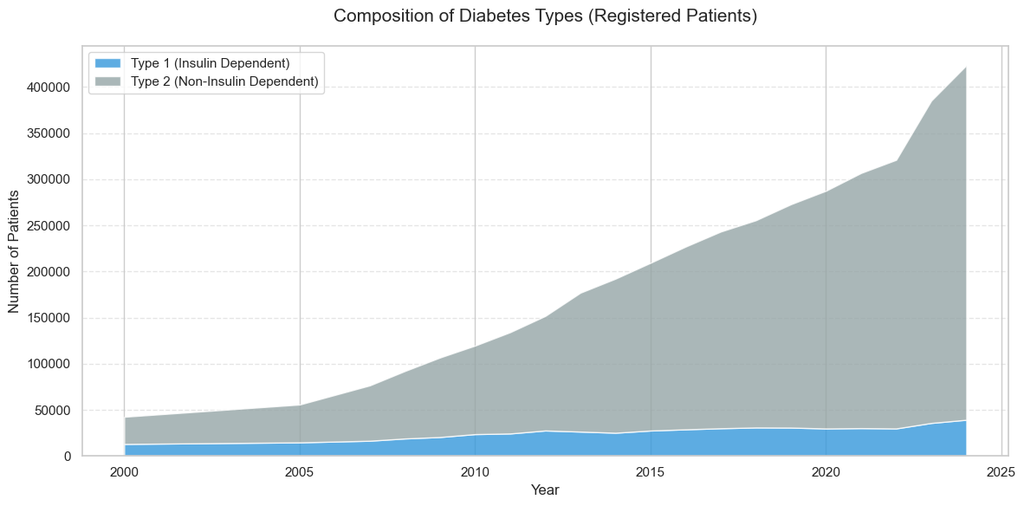

```python
plt.figure(figsize=(12, 6))

# Create an area chart to visualize the composition

plt.stackplot(df_count['Year'],
              df_count['Registered_Type1'],
              df_count['Registered_Type2'],
              labels=['Type 1 (Insulin Dependent)', 'Type 2 (Non-Insulin Dependent)'],
              colors=['#3498db', '#95a5a6'], alpha=0.8)

plt.title('Composition of Diabetes Types (Registered Patients)', fontsize=15, pad=20)
plt.xlabel('Year', fontsize=12)
plt.ylabel('Number of Patients', fontsize=12)
plt.legend(loc='upper left')
plt.grid(axis='y', linestyle='--', alpha=0.5)

plt.tight_layout()
plt.show()
```

**Type 2 diabetes accounts for the majority of registered cases and is the main driver of the overall increase in diabetes prevalence over time. While Type 1 diabetes shows a gradual rise in absolute numbers, its share remains relatively small and decreases proportionally as total cases grow. The widening gap between Type 1 and Type 2 indicates a structural shift in disease composition toward Type 2 dominance. Overall, the trend suggests a steadily increasing diabetes burden driven primarily by Type 2 diabetes.**

```python
# Calculate the growth rate

total_growth = ((df_count.iloc[-1]['Registered_Total'] - df_count.iloc[0]['Registered_Total']) / df_count.iloc[0]['Registered_Total']) * 100
type2_ratio = (df_count.iloc[-1]['Registered_Type2'] / df_count.iloc[-1]['Registered_Total']) * 100

print("KEY INSIGHTS:")
print(f"1. Total registered diabetes cases have grown by {total_growth:.1f}% since 2000.")
print(f"2. In 2024, Type 2 diabetes accounts for {type2_ratio:.1f}% of all registered cases.")
print("3. The magnitude of growth suggests a structural increase rather than a purely demographic effect.")
```

```
KEY INSIGHTS:
1. Total registered diabetes cases have grown by 897.7% since 2000.
2. In 2024, Type 2 diabetes accounts for 90.7% of all registered cases.
3. The magnitude of growth suggests a structural increase rather than a purely demographic effect.
```

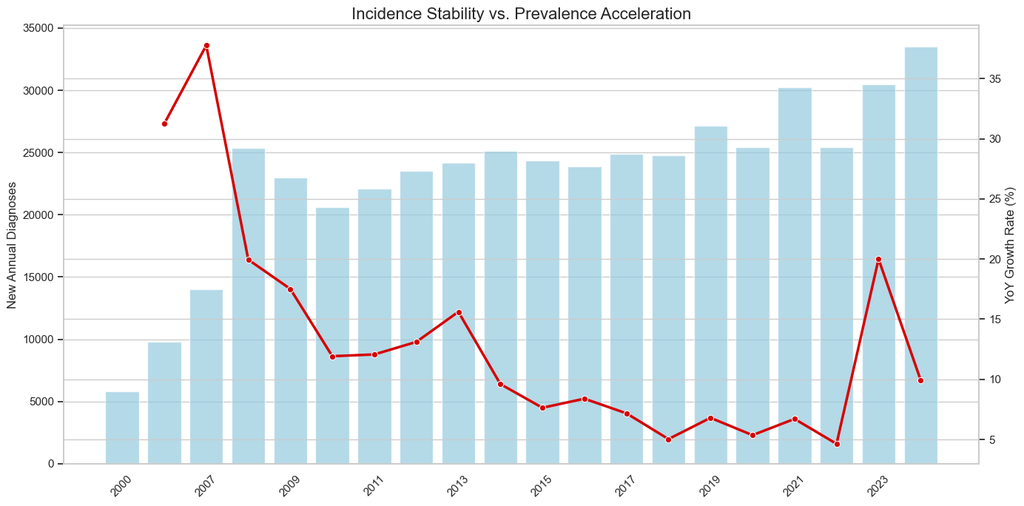

```python
df_plot = df_count.sort_values('Year').copy()
x = range(len(df_plot))

plt.figure(figsize=(14, 7))
sns.set_style("whitegrid")

ax = sns.barplot(x=x, y=df_plot['New_Cases_Total'], color='#87CEEB', alpha=0.7)

ax2 = ax.twinx()
sns.lineplot(x=x, y=df_plot['Registered_Total'].pct_change() * 100,
             color='#D50000', marker='o', linewidth=2.5, ax=ax2)

# Display Year labels on the x-axis

ax.set_xticks(list(x)[::2])
ax.set_xticklabels(df_plot['Year'].astype(int).tolist()[::2], rotation=45)

plt.title('Incidence Stability vs. Prevalence Acceleration', fontsize=16)
ax.set_ylabel('New Annual Diagnoses', fontsize=12)
ax2.set_ylabel('YoY Growth Rate (%)', fontsize=12)
plt.tight_layout()
plt.show()
```

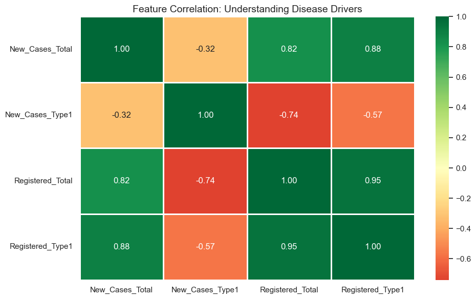

```python
plt.figure(figsize=(10, 6))

corr = df_count[[
    'New_Cases_Total',
    'New_Cases_Type1',
    'Registered_Total',
    'Registered_Type1'
]].corr()

sns.heatmap(corr, annot=True, cmap='RdYlGn', center=0, linewidths=2, fmt=".2f")
plt.title('Feature Correlation: Understanding Disease Drivers', fontsize=14)
plt.tight_layout()
plt.show()
```

### Executive Insight:

**Total diabetes prevalence is strongly associated with overall new case incidence, indicating that sustained registrations are linked to long-term increases in disease burden. In contrast, Type 1 incidence shows a negative relationship with total prevalence metrics, suggesting that it is less closely related to overall prevalence growth. Together, these patterns suggest a relationship in which changes in total diabetes prevalence are primarily aligned with non–Type 1 dynamics and the long-term accumulation of chronic cases.**

```python
from sklearn.linear_model import LinearRegression
import numpy as np
import plotly.graph_objects as go

# Prediction model
X = df_count['Year'].values.reshape(-1, 1)
y = df_count['Registered_Total'].values

model = LinearRegression().fit(X, y)

future_years = np.array(range(2025, 2031)).reshape(-1, 1)
preds = model.predict(future_years)

fig4 = go.Figure()
fig4.add_trace(
    go.Scatter(
        x=df_count['Year'],
        y=y,
        name='Historical',
        mode='lines+markers'
    )
)

fig4.add_trace(
    go.Scatter(
        x=list(range(2025, 2031)),
        y=preds,
        name='Linear Trend Projection',
        line=dict(dash='dash', color='red')
    )
)

fig4.update_layout(
    title='<b>Linear Trend Projection of Diabetes Prevalence (2025–2030)</b>',
    xaxis_title='Year',
    yaxis_title='Predicted Total Patients',
    template='plotly_dark'
)

fig4.show()

r2 = model.score(X, y)
print(f"Model R² (in-sample): {r2:.3f}")
```

[interactive chart not shown]

```
Model R² (in-sample): 0.948
```

### Diabetes Trend Projection (2025–2030)

> **Insight:**

The forecast shows that the number of registered diabetes patients is expected to keep increasing in the coming years. There is no sign of the trend slowing down, which means the overall disease burden will likely continue to grow. This increase may put additional pressure on hospitals, doctors, and long-term treatment services. The projection is based on past trends and shows a general direction rather than an exact prediction. Changes in healthcare policy or prevention programs could alter this outcome.

```python
# Create a base year (2000) for comparison
base_values = df_count.iloc[0][['New_Cases_Total', 'Registered_Total']]
df_count['New_Index'] = (df_count['New_Cases_Total'] / base_values['New_Cases_Total']) * 100
df_count['Reg_Index'] = (df_count['Registered_Total'] / base_values['Registered_Total']) * 100

fig_index = go.Figure()
fig_index.add_trace(go.Scatter(x=df_count['Year'], y=df_count['New_Index'], name='New Cases Index'))
fig_index.add_trace(go.Scatter(x=df_count['Year'], y=df_count['Reg_Index'], name='Prevalence Index'))

fig_index.update_layout(title='<b>Relative Growth Index (Base Year 2000 = 100)</b>',
                  yaxis_title='Percentage of 2013 levels', template='plotly_white')
fig_index.show()
```

[interactive chart not shown]

```python
df_count['Insulin_Percent'] = (df_count['Registered_Type1'] / df_count['Registered_Total']) * 100

fig_perc = px.area(df_count, x='Year', y='Insulin_Percent',
                  title='<b>Shift in Treatment: Insulin-Dependent Share of Total Patients</b>',
                  color_discrete_sequence=['#AB63FA'])
fig_perc.update_layout(
    yaxis_title='Percentage (%)',xaxis_title='Year',yaxis_range=[0, df_count['Insulin_Percent'].max() + 5],template='plotly_white')
fig_perc.show()
```

[interactive chart not shown]

**The share of insulin-dependent (Type 1) diabetes patients has steadily declined over time, even as total diabetes prevalence increased. This indicates that growth in overall diabetes burden is not driven by insulin-dependent cases. Instead, non-insulin-dependent diabetes plays an increasingly dominant role in shaping treatment demand.**

[figure not shown]

```python
plt.figure(figsize=(10, 5))
sns.boxplot(data=df_count[['New_Cases_Type1', 'New_Cases_Type2']], palette="Set2")
plt.title('Distribution and Variance of New Annual Cases (2013-2024)')
plt.ylabel('Number of Patients')
plt.xlabel('Diabetes Type')
plt.xticks(ticks=[0, 1],labels=['Type 1 (Insulin)', 'Type 2 (Non-Insulin)'])
plt.tight_layout()
plt.show()
```

**Type 2 (non-insulin) diabetes shows a much higher median and wider spread in new annual cases compared to Type 1, indicating both greater incidence and higher variability. In contrast, Type 1 (insulin-dependent) cases remain relatively low and stable over time. This highlights that fluctuations and growth in new diabetes diagnoses are primarily driven by Type 2 diabetes.**

```python
# Attrition logic:
# Expected_Total = (previous year's registered total) + (current year's new cases)
# Exit_Cases = Expected_Total - (current year's registered total)
df_count = df_count.sort_values('Year').copy()

df_count['Expected_Total'] = df_count['Registered_Total'].shift(1) + df_count['New_Cases_Total']
df_count['Exit_Cases'] = df_count['Expected_Total'] - df_count['Registered_Total']

# Drop the first year (no previous year to compare)
df_plot = df_count.dropna(subset=['Exit_Cases']).copy()

fig_exit = go.Figure()
fig_exit.add_trace(go.Bar(
    x=df_plot['Year'],
    y=df_plot['Exit_Cases'],
    name='Estimated Attrition (Exit from Registry)',
    marker_color='slategray'
))

fig_exit.update_layout(
    title='<b>Estimated Annual Patient Attrition (Registry Exits)</b>',
    xaxis_title='Year',
    yaxis_title='Estimated Number of People',
    template='plotly_white'
)

fig_exit.show()
```

[interactive chart not shown]

### Insight: Estimated Registry Exits (Attrition Proxy)

**The chart shows that each year a noticeable number of patients exit the diabetes registry, even as total prevalence continues to grow. This indicates that the registry is dynamic, with exits partially offsetting new registrations rather than cases accumulating indefinitely. The sharp negative spike in recent years suggests a one-off correction or structural change in registration practices rather than a sudden real-world drop in patients.**

```python
# 1. Calculate the lifecycle metrics
df_count['Expected_Total'] = df_count['Registered_Total'].shift(1) + df_count['New_Cases_Total']
df_count['Exit_Cases'] = df_count['Expected_Total'] - df_count['Registered_Total']

# 2. Create the Lifecycle Visualization
fig_lifecycle = go.Figure()

# Inflow - New Patients
fig_lifecycle.add_trace(go.Bar(
    x=df_count['Year'], y=df_count['New_Cases_Total'],
    name='Patient Inflow (New Cases)', marker_color='#00CC96'
))

# Outflow - Patients exiting (Mortality/Migration)
fig_lifecycle.add_trace(go.Bar(
    x=df_count['Year'], y=-df_count['Exit_Cases'],
    name='Patient Outflow (Exit/Attrition)', marker_color='#EF553B'
))

fig_lifecycle.update_layout(
    title='<b>Diabetes Lifecycle: Annual Inflow vs. Outflow</b>',
    barmode='relative',
    xaxis_title='Year', yaxis_title='Number of Patients',
    template='plotly_white',
    legend=dict(orientation="h", yanchor="bottom", y=1.02, xanchor="right", x=1)
)

fig_lifecycle.show()
```

[interactive chart not shown]

### Insight: Diabetes Lifecycle – Annual Inflow vs. Outflow

**The chart shows that new diabetes registrations consistently exceed patient exits, explaining the steady growth in total prevalence over time. Although a significant number of patients leave the registry each year, inflow remains dominant, resulting in net accumulation of chronic cases. Periods with elevated outflow likely reflect registry updates or structural adjustments rather than true reductions in disease burden. Overall, the lifecycle pattern highlights diabetes as a long-term condition with persistent system-level accumulation.**

```python
fig_final = px.line(df_count, x='Year', y='Registered_Total', title='<b>Diabetes Growth with Contextual Events</b>')

fig_final.add_annotation(x=2020, y=df_count[df_count['Year']==2020]['Registered_Total'].values[0],
            text="COVID-19 Impact: Potential under-registration",
            showarrow=True, arrowhead=1)

fig_final.add_annotation(x=2024, y=df_count[df_count['Year']==2024]['Registered_Total'].values[0],
            text="Peak Prevalence Detected",
            showarrow=True, arrowhead=2, ay=-40)

fig_final.show()
```

[interactive chart not shown]

# Conclusion & Strategic Recommendations

Based on the visual evidence and statistical forecasting, the following strategic insights are recommended:

### 1. Shift to Preventive Care

Since diabetes growth is driven primarily by non-insulin-dependent (Type 2) cases, national health policies should prioritize lifestyle awareness, early screening, and obesity prevention programs.

### 2. Infrastructure Readiness

The trend-based forecast indicates a substantial increase in patient volume over the next five years. Healthcare infrastructure should proactively expand its capacity for long-term chronic disease management and follow-up care.

### 3. Data-Driven Monitoring

Fluctuations observed in the estimated attrition rate highlight the need for improved patient tracking systems. Better differentiation between mortality, migration, and registry adjustments is essential for accurate prevalence monitoring and planning.